# Ciencia de Datos para Políticas Públicas

## Pivot_wider

```r
table2
```

```
## # A tibble: 12 x 4
##    country      year type            count
##    <chr>       <int> <chr>           <int>
##  1 Afghanistan  1999 cases             745
##  2 Afghanistan  1999 population   19987071
##  3 Afghanistan  2000 cases            2666
##  4 Afghanistan  2000 population   20595360
##  5 Brazil       1999 cases           37737
##  6 Brazil       1999 population  172006362
##  7 Brazil       2000 cases           80488
##  8 Brazil       2000 population  174504898
##  9 China        1999 cases          212258
## 10 China        1999 population 1272915272
## 11 China        2000 cases          213766
## 12 China        2000 population 1280428583
```

```r
table2 %>%
  pivot_wider(names_from = type,
              values_from = count)
```

```
## # A tibble: 6 x 4
##   country      year  cases population
##   <chr>       <int>  <int>      <int>
## 1 Afghanistan  1999    745   19987071
## 2 Afghanistan  2000   2666   20595360
## 3 Brazil       1999  37737  172006362
## 4 Brazil       2000  80488  174504898
## 5 China        1999 212258 1272915272
## 6 China        2000 213766 1280428583
```

## `tidyr`

### Principales funciones (ii)

- `pivot_longer`

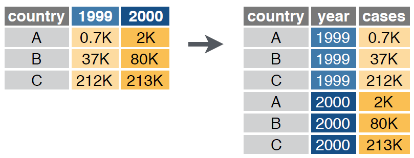

## Pivot_longer

```r
table4a
```

```
## # A tibble: 3 x 3
##   country     `1999` `2000`
## * <chr>        <int>  <int>
## 1 Afghanistan    745   2666
## 2 Brazil       37737  80488
## 3 China       212258 213766
```

```r
table4a %>%
  pivot_longer(2:3,
               names_to = "year",
               values_to = "value")
```

```
## # A tibble: 6 x 3
##   country     year   value
##   <chr>       <chr>  <int>
## 1 Afghanistan 1999     745
## 2 Afghanistan 2000    2666
## 3 Brazil      1999   37737
## 4 Brazil      2000   80488
## 5 China       1999  212258
## 6 China       2000  213766
```

## Demo - Enfermedades respiratorias

## Demo

### Script

- `Clase04_TransformacionDatosI.R`

## Enfermedades respiratorias

```r
glimpse(who)
```

```
## Rows: 7,240
## Columns: 60
## $ country      <chr> "Afghanistan", "Afghanistan", "Afghanistan", "Afghanis...
## $ iso2         <chr> "AF", "AF", "AF", "AF", "AF", "AF", "AF", "AF", "AF", ...
## $ iso3         <chr> "AFG", "AFG", "AFG", "AFG", "AFG", "AFG", "AFG", "AFG"...
## $ year         <int> 1980, 1981, 1982, 1983, 1984, 1985, 1986, 1987, 1988, ...
## $ new_sp_m014  <int> NA, NA, NA, NA, NA, NA, NA, NA, NA, NA, NA, NA, NA, NA...
## $ new_sp_m1524 <int> NA, NA, NA, NA, NA, NA, NA, NA, NA, NA, NA, NA, NA, NA...
## $ new_sp_m2534 <int> NA, NA, NA, NA, NA, NA, NA, NA, NA, NA, NA, NA, NA, NA...
## $ new_sp_m3544 <int> NA, NA, NA, NA, NA, NA, NA, NA, NA, NA, NA, NA, NA, NA...
## $ new_sp_m4554 <int> NA, NA, NA, NA, NA, NA, NA, NA, NA, NA, NA, NA, NA, NA...
## $ new_sp_m5564 <int> NA, NA, NA, NA, NA, NA, NA, NA, NA, NA, NA, NA, NA, NA...
## $ new_sp_m65   <int> NA, NA, NA, NA, NA, NA, NA, NA, NA, NA, NA, NA, NA, NA...
## $ new_sp_f014  <int> NA, NA, NA, NA, NA, NA, NA, NA, NA, NA, NA, NA, NA, NA...
## $ new_sp_f1524 <int> NA, NA, NA, NA, NA, NA, NA, NA, NA, NA, NA, NA, NA, NA...
```

[output cut: 47 more lines]

## Donde comenzamos

```r
(enfermedades <- who %>%
  select(-iso2, -iso3))
```

```
## # A tibble: 7,240 x 58
##    country  year new_sp_m014 new_sp_m1524 new_sp_m2534 new_sp_m3544 new_sp_m4554
##    <chr>   <int>       <int>        <int>        <int>        <int>        <int>
##  1 Afghan~  1980          NA           NA           NA           NA           NA
##  2 Afghan~  1981          NA           NA           NA           NA           NA
##  3 Afghan~  1982          NA           NA           NA           NA           NA
##  4 Afghan~  1983          NA           NA           NA           NA           NA
##  5 Afghan~  1984          NA           NA           NA           NA           NA
##  6 Afghan~  1985          NA           NA           NA           NA           NA
##  7 Afghan~  1986          NA           NA           NA           NA           NA
##  8 Afghan~  1987          NA           NA           NA           NA           NA
##  9 Afghan~  1988          NA           NA           NA           NA           NA
## 10 Afghan~  1989          NA           NA           NA           NA           NA
## # ... with 7,230 more rows, and 51 more variables: new_sp_m5564 <int>,
## #   new_sp_m65 <int>, new_sp_f014 <int>, new_sp_f1524 <int>,
## #   new_sp_f2534 <int>, new_sp_f3544 <int>, new_sp_f4554 <int>,
## #   new_sp_f5564 <int>, new_sp_f65 <int>, new_sn_m014 <int>,
## #   new_sn_m1524 <int>, new_sn_m2534 <int>, new_sn_m3544 <int>,
## #   new_sn_m4554 <int>, new_sn_m5564 <int>, new_sn_m65 <int>,
## #   new_sn_f014 <int>, new_sn_f1524 <int>, new_sn_f2534 <int>,
## #   new_sn_f3544 <int>, new_sn_f4554 <int>, new_sn_f5564 <int>,
## #   new_sn_f65 <int>, new_ep_m014 <int>, new_ep_m1524 <int>,
## #   new_ep_m2534 <int>, new_ep_m3544 <int>, new_ep_m4554 <int>,
## #   new_ep_m5564 <int>, new_ep_m65 <int>, new_ep_f014 <int>,
## #   new_ep_f1524 <int>, new_ep_f2534 <int>, new_ep_f3544 <int>,
## #   new_ep_f4554 <int>, new_ep_f5564 <int>, new_ep_f65 <int>,
## #   newrel_m014 <int>, newrel_m1524 <int>, newrel_m2534 <int>,
## #   newrel_m3544 <int>, newrel_m4554 <int>, newrel_m5564 <int>,
## #   newrel_m65 <int>, newrel_f014 <int>, newrel_f1524 <int>,
## #   newrel_f2534 <int>, newrel_f3544 <int>, newrel_f4554 <int>,
## #   newrel_f5564 <int>, newrel_f65 <int>
```

## Donde queremos llegar

```r
tabla_final
```

```
## # A tibble: 2 x 8
## # Groups:   sexo [2]
##   sexo    `0-14` `15-24` `25-34` `35-44` `45-54` `55-64`  `65+`
##   <chr>    <int>   <int>   <int>   <int>   <int>   <int>  <int>
## 1 hombres  97051  406084  495242  478700  417188  325188 288063
## 2 mujeres  99738  320620  347398  260839  184791  136441 129468
```

- ¿Edad?
- ¿Sexo?

## ¿Qué información tenemos disponible?

```r
names(enfermedades)
```

```
##  [1] "country"      "year"         "new_sp_m014"  "new_sp_m1524" "new_sp_m2534"
##  [6] "new_sp_m3544" "new_sp_m4554" "new_sp_m5564" "new_sp_m65"   "new_sp_f014"
## [11] "new_sp_f1524" "new_sp_f2534" "new_sp_f3544" "new_sp_f4554" "new_sp_f5564"
## [16] "new_sp_f65"   "new_sn_m014"  "new_sn_m1524" "new_sn_m2534" "new_sn_m3544"
## [21] "new_sn_m4554" "new_sn_m5564" "new_sn_m65"   "new_sn_f014"  "new_sn_f1524"
## [26] "new_sn_f2534" "new_sn_f3544" "new_sn_f4554" "new_sn_f5564" "new_sn_f65"
## [31] "new_ep_m014"  "new_ep_m1524" "new_ep_m2534" "new_ep_m3544" "new_ep_m4554"
## [36] "new_ep_m5564" "new_ep_m65"   "new_ep_f014"  "new_ep_f1524" "new_ep_f2534"
## [41] "new_ep_f3544" "new_ep_f4554" "new_ep_f5564" "new_ep_f65"   "newrel_m014"
## [46] "newrel_m1524" "newrel_m2534" "newrel_m3544" "newrel_m4554" "newrel_m5564"
## [51] "newrel_m65"   "newrel_f014"  "newrel_f1524" "newrel_f2534" "newrel_f3544"
## [56] "newrel_f4554" "newrel_f5564" "newrel_f65"
```

- **[*new o new_*]+[*enfermedad*]+[_]+[*sexo*]+[*RangoEdad*]**

## ¿Pivot_ … longer o wider?

```r
enfermedades
```

```
## # A tibble: 7,240 x 58
##    country  year new_sp_m014 new_sp_m1524 new_sp_m2534 new_sp_m3544 new_sp_m4554
##    <chr>   <int>       <int>        <int>        <int>        <int>        <int>
##  1 Afghan~  1980          NA           NA           NA           NA           NA
##  2 Afghan~  1981          NA           NA           NA           NA           NA
##  3 Afghan~  1982          NA           NA           NA           NA           NA
##  4 Afghan~  1983          NA           NA           NA           NA           NA
##  5 Afghan~  1984          NA           NA           NA           NA           NA
##  6 Afghan~  1985          NA           NA           NA           NA           NA
##  7 Afghan~  1986          NA           NA           NA           NA           NA
##  8 Afghan~  1987          NA           NA           NA           NA           NA
##  9 Afghan~  1988          NA           NA           NA           NA           NA
## 10 Afghan~  1989          NA           NA           NA           NA           NA
## # ... with 7,230 more rows, and 51 more variables: new_sp_m5564 <int>,
## #   new_sp_m65 <int>, new_sp_f014 <int>, new_sp_f1524 <int>,
## #   new_sp_f2534 <int>, new_sp_f3544 <int>, new_sp_f4554 <int>,
## #   new_sp_f5564 <int>, new_sp_f65 <int>, new_sn_m014 <int>,
## #   new_sn_m1524 <int>, new_sn_m2534 <int>, new_sn_m3544 <int>,
## #   new_sn_m4554 <int>, new_sn_m5564 <int>, new_sn_m65 <int>,
## #   new_sn_f014 <int>, new_sn_f1524 <int>, new_sn_f2534 <int>,
## #   new_sn_f3544 <int>, new_sn_f4554 <int>, new_sn_f5564 <int>,
## #   new_sn_f65 <int>, new_ep_m014 <int>, new_ep_m1524 <int>,
## #   new_ep_m2534 <int>, new_ep_m3544 <int>, new_ep_m4554 <int>,
## #   new_ep_m5564 <int>, new_ep_m65 <int>, new_ep_f014 <int>,
## #   new_ep_f1524 <int>, new_ep_f2534 <int>, new_ep_f3544 <int>,
## #   new_ep_f4554 <int>, new_ep_f5564 <int>, new_ep_f65 <int>,
## #   newrel_m014 <int>, newrel_m1524 <int>, newrel_m2534 <int>,
## #   newrel_m3544 <int>, newrel_m4554 <int>, newrel_m5564 <int>,
## #   newrel_m65 <int>, newrel_f014 <int>, newrel_f1524 <int>,
## #   newrel_f2534 <int>, newrel_f3544 <int>, newrel_f4554 <int>,
## #   newrel_f5564 <int>, newrel_f65 <int>
```

## ¿Pivot_ … longer o wider?

## Transformamos la forma de nuestros datos

```r
(enfermedades2 <- enfermedades %>%
  pivot_longer(-c(country:year),
               names_to = "variables",
               values_to = "valores"))
```

```
## # A tibble: 405,440 x 4
##    country      year variables    valores
##    <chr>       <int> <chr>          <int>
##  1 Afghanistan  1980 new_sp_m014       NA
##  2 Afghanistan  1980 new_sp_m1524      NA
##  3 Afghanistan  1980 new_sp_m2534      NA
##  4 Afghanistan  1980 new_sp_m3544      NA
##  5 Afghanistan  1980 new_sp_m4554      NA
##  6 Afghanistan  1980 new_sp_m5564      NA
##  7 Afghanistan  1980 new_sp_m65        NA
##  8 Afghanistan  1980 new_sp_f014       NA
##  9 Afghanistan  1980 new_sp_f1524      NA
## 10 Afghanistan  1980 new_sp_f2534      NA
## # ... with 405,430 more rows
```

- Tenemos una columna que contiene tres variables pero también una parte que no nos sirve mucho.

## stringr

[interactive chart not shown]

## Eliminaremos parte de la columna “variables” que no nos sirve

```r
(enfermedades3 <- enfermedades2 %>%
  mutate(variables = str_remove(variables, "new_"),
         variables = str_remove(variables, "new")))
```

```
## # A tibble: 405,440 x 4
##    country      year variables valores
##    <chr>       <int> <chr>       <int>
##  1 Afghanistan  1980 sp_m014        NA
##  2 Afghanistan  1980 sp_m1524       NA
##  3 Afghanistan  1980 sp_m2534       NA
##  4 Afghanistan  1980 sp_m3544       NA
##  5 Afghanistan  1980 sp_m4554       NA
##  6 Afghanistan  1980 sp_m5564       NA
##  7 Afghanistan  1980 sp_m65         NA
##  8 Afghanistan  1980 sp_f014        NA
##  9 Afghanistan  1980 sp_f1524       NA
## 10 Afghanistan  1980 sp_f2534       NA
## # ... with 405,430 more rows
```

- Ahora tenemos una columna que contiene tres variables. ¿Cómo las separamos?

## `separate` (i)

```r
enfermedades3
```

```
## # A tibble: 405,440 x 4
##    country      year variables valores
##    <chr>       <int> <chr>       <int>
##  1 Afghanistan  1980 sp_m014        NA
##  2 Afghanistan  1980 sp_m1524       NA
##  3 Afghanistan  1980 sp_m2534       NA
##  4 Afghanistan  1980 sp_m3544       NA
##  5 Afghanistan  1980 sp_m4554       NA
##  6 Afghanistan  1980 sp_m5564       NA
##  7 Afghanistan  1980 sp_m65         NA
##  8 Afghanistan  1980 sp_f014        NA
##  9 Afghanistan  1980 sp_f1524       NA
## 10 Afghanistan  1980 sp_f2534       NA
## # ... with 405,430 more rows
```

```r
(enfermedades4 <- enfermedades3 %>%
  separate(variables,
           into = c("enfermedad", "otro"),
           sep = "_"))
```

```
## # A tibble: 405,440 x 5
##    country      year enfermedad otro  valores
##    <chr>       <int> <chr>      <chr>   <int>
##  1 Afghanistan  1980 sp         m014       NA
##  2 Afghanistan  1980 sp         m1524      NA
##  3 Afghanistan  1980 sp         m2534      NA
##  4 Afghanistan  1980 sp         m3544      NA
##  5 Afghanistan  1980 sp         m4554      NA
##  6 Afghanistan  1980 sp         m5564      NA
##  7 Afghanistan  1980 sp         m65        NA
##  8 Afghanistan  1980 sp         f014       NA
##  9 Afghanistan  1980 sp         f1524      NA
## 10 Afghanistan  1980 sp         f2534      NA
## # ... with 405,430 more rows
```

## `separate` (ii)

```r
enfermedades4
```

```
## # A tibble: 405,440 x 5
##    country      year enfermedad otro  valores
##    <chr>       <int> <chr>      <chr>   <int>
##  1 Afghanistan  1980 sp         m014       NA
##  2 Afghanistan  1980 sp         m1524      NA
##  3 Afghanistan  1980 sp         m2534      NA
##  4 Afghanistan  1980 sp         m3544      NA
##  5 Afghanistan  1980 sp         m4554      NA
##  6 Afghanistan  1980 sp         m5564      NA
##  7 Afghanistan  1980 sp         m65        NA
##  8 Afghanistan  1980 sp         f014       NA
##  9 Afghanistan  1980 sp         f1524      NA
## 10 Afghanistan  1980 sp         f2534      NA
## # ... with 405,430 more rows
```

```r
(enfermedades5 <- enfermedades4 %>%
  separate(otro,
           into = c("sexo", "edad"),
           sep =  1))
```

```
## # A tibble: 405,440 x 6
##    country      year enfermedad sexo  edad  valores
##    <chr>       <int> <chr>      <chr> <chr>   <int>
##  1 Afghanistan  1980 sp         m     014        NA
##  2 Afghanistan  1980 sp         m     1524       NA
##  3 Afghanistan  1980 sp         m     2534       NA
##  4 Afghanistan  1980 sp         m     3544       NA
##  5 Afghanistan  1980 sp         m     4554       NA
##  6 Afghanistan  1980 sp         m     5564       NA
##  7 Afghanistan  1980 sp         m     65         NA
##  8 Afghanistan  1980 sp         f     014        NA
##  9 Afghanistan  1980 sp         f     1524       NA
## 10 Afghanistan  1980 sp         f     2534       NA
## # ... with 405,430 more rows
```

## Se podría llegar a lo mismo usando `stringr`

```r
enfermedades2 %>%
  transmute(country, year,

    enfermedad = case_when(
      str_detect(variables, "rel") ~
        str_sub(variables, 4, 6),
      TRUE ~ str_sub(variables, 5,6)),

    sexo = case_when(
      str_detect(variables, "m") ~ "m",
      TRUE ~ "f"),

    edad = str_extract(variables, "\\d+"),
    valores
    )
```

```
## # A tibble: 405,440 x 6
##    country      year enfermedad sexo  edad  valores
##    <chr>       <int> <chr>      <chr> <chr>   <int>
##  1 Afghanistan  1980 sp         m     014        NA
##  2 Afghanistan  1980 sp         m     1524       NA
##  3 Afghanistan  1980 sp         m     2534       NA
##  4 Afghanistan  1980 sp         m     3544       NA
##  5 Afghanistan  1980 sp         m     4554       NA
##  6 Afghanistan  1980 sp         m     5564       NA
##  7 Afghanistan  1980 sp         m     65         NA
##  8 Afghanistan  1980 sp         f     014        NA
##  9 Afghanistan  1980 sp         f     1524       NA
## 10 Afghanistan  1980 sp         f     2534       NA
## # ... with 405,430 more rows
```

## Modificaremos algunos valores para mayor claridad

```r
(enfermedades6 <- enfermedades5 %>%
  mutate(
    edad = case_when(
      edad == "014" ~ "0-14",
      edad == "1524" ~ "15-24",
      edad == "2534" ~ "25-34",
      edad == "3544" ~ "35-44",
      edad == "4554" ~ "45-54",
      edad == "5564" ~ "55-64",
      edad == "65" ~ "65+"
    ),
    sexo = case_when(
      sexo == "m" ~ "hombres",
      sexo == "f" ~ "mujeres"
    )))
```

```
## # A tibble: 405,440 x 6
##    country      year enfermedad sexo    edad  valores
##    <chr>       <int> <chr>      <chr>   <chr>   <int>
##  1 Afghanistan  1980 sp         hombres 0-14       NA
##  2 Afghanistan  1980 sp         hombres 15-24      NA
##  3 Afghanistan  1980 sp         hombres 25-34      NA
##  4 Afghanistan  1980 sp         hombres 35-44      NA
##  5 Afghanistan  1980 sp         hombres 45-54      NA
##  6 Afghanistan  1980 sp         hombres 55-64      NA
##  7 Afghanistan  1980 sp         hombres 65+        NA
##  8 Afghanistan  1980 sp         mujeres 0-14       NA
##  9 Afghanistan  1980 sp         mujeres 15-24      NA
## 10 Afghanistan  1980 sp         mujeres 25-34      NA
## # ... with 405,430 more rows
```

## Calculamos el total de enfermedades por sexo y rango de edad

```r
(resumen_enfermedades <- enfermedades6 %>%
  filter(year == 2010) %>%
  group_by(sexo, edad) %>%
  summarise(total = sum(valores, na.rm = TRUE)))
```

```
## # A tibble: 14 x 3
## # Groups:   sexo [2]
##    sexo    edad   total
##    <chr>   <chr>  <int>
##  1 hombres 0-14   97051
##  2 hombres 15-24 406084
##  3 hombres 25-34 495242
##  4 hombres 35-44 478700
##  5 hombres 45-54 417188
##  6 hombres 55-64 325188
##  7 hombres 65+   288063
##  8 mujeres 0-14   99738
##  9 mujeres 15-24 320620
## 10 mujeres 25-34 347398
## 11 mujeres 35-44 260839
## 12 mujeres 45-54 184791
## 13 mujeres 55-64 136441
## 14 mujeres 65+   129468
```

## `Pivot_wider` para dar la forma final a la tabla

```r
(tabla_final <- resumen_enfermedades %>%
  pivot_wider(names_from = edad, values_from = total))
```

```
## # A tibble: 2 x 8
## # Groups:   sexo [2]
##   sexo    `0-14` `15-24` `25-34` `35-44` `45-54` `55-64`  `65+`
##   <chr>    <int>   <int>   <int>   <int>   <int>   <int>  <int>
## 1 hombres  97051  406084  495242  478700  417188  325188 288063
## 2 mujeres  99738  320620  347398  260839  184791  136441 129468
```

## Resumen

```r
tabla_final <- who %>%
  # Eliminar columnas que no usaremos
  select(-iso2, -iso3) %>%
  # Ajustar forma de los datos (de ancho a largo)
  pivot_longer(-c(country:year), names_to = "variables", values_to = "valores", values_drop_na = TRUE) %>%
  # Extraer información de la columna "variables
  mutate(variables = str_remove(variables, "new_"),
         variables = str_remove(variables, "new")) %>%
  separate(variables, into = c("enfermedad", "otro"), sep = "_") %>%
  separate(otro, into = c("sexo", "edad"), sep =  1) %>%
  # Re-codificar las columnas edad y sexo
  mutate(edad = case_when(
    edad == "014" ~ "0-14",
    edad == "1524" ~ "15-24",
    edad == "2534" ~ "25-34",
    edad == "3544" ~ "35-44",
    edad == "4554" ~ "45-54",
    edad == "5564" ~ "55-64",
    edad == "65" ~ "65+"),
    sexo = case_when(
      sexo == "m" ~ "hombres",
      sexo == "f" ~ "mujeres")) %>%
  # Generar tabla final para el año 2010
  filter(year == 2010) %>%
  group_by(sexo, edad) %>%
  summarise(total = sum(valores, na.rm = TRUE)) %>%
  pivot_wider(names_from = edad, values_from = total)
```

## Ejercicio

## Ejercicio

### Script

- `Clase04_EjercicioI.R`

## Funciones e iteraciones

## Funciones

- Hasta ahora hemos visto funciones que vienen por defecto en `R` o en paquetes que cargamos
- Pero también podemos generar nuestras propias funciones
  - ¿Para qué?
- Si se encuentran con un script que repite muchas veces (¿más de 3?) probablemente sea necesaria una función

## ¿Cómo se crea una función?

- Una función tiene tres partes
  - Nombre
  - Argumentos
  - Cuerpo

```r
ElevaryDividir <- function(x, y, z){
  (x^y)/z
}

ElevaryDividir(3, 2, 4)
```

```
## [1] 2.25
```

## Ejemplo

Estamos explorando datos y queremos ir graficando distintos indicadores para distintos países

```r
datosONU_tidy <- read_csv("datos/DatosONU_tidy.csv")

datosONU_tidy %>%
  filter(country_name == "Chile") %>%
  ggplot(aes(x = year, y = population_total)) +
  geom_point() +
  geom_line() +
  labs(x = NULL) +
  theme_minimal()
```

[output not shown]

## Crear una función que haga esto

```r
graf_indicador_pais <- function(x, y){

  y <- enquo(y)

  datosONU_tidy %>%
  filter(country_name == x) %>%
  ggplot(aes(x = year, y = !!y)) +
  geom_point() +
  geom_line() +
  labs(x = NULL) +
  theme_minimal()

}
```

```r
graf_indicador_pais("Chile", population_total)
```

[output not shown]

## Y ahora podemos hacer muchas cosas más

```r
graf_indicador_pais("Chile", population_total)
```

```r
graf_indicador_pais("Argentina",
                    gdp_per_capita_constant_2005_us)
```

[output not shown]

## Iteraciones

### ¿Para qué?

Digamos que queremos graficar el mismo indicador para varios países:

```r
graf_indicador_pais("Chile", gdp_per_capita_constant_2005_us)
graf_indicador_pais("Argentina", gdp_per_capita_constant_2005_us)
graf_indicador_pais("United States", gdp_per_capita_constant_2005_us)
```

## Antes de seguir

### Tipos de objetos

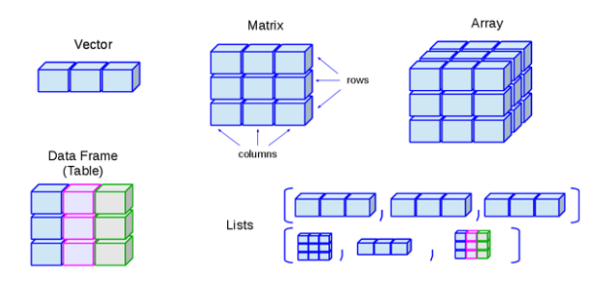

## `for` loops

```r
for (i in 1:10){
  print(2^i)
}
```

```
## [1] 2
## [1] 4
## [1] 8
## [1] 16
## [1] 32
## [1] 64
## [1] 128
## [1] 256
## [1] 512
## [1] 1024
```

## `for` loop aplicado a nuestro ejemplo

```r
graficos <- list()
paises <- c("Chile", "Argentina", "United States")
for (i in seq_along(paises)){
  graficos[[i]] <- graf_indicador_pais(paises[i], gdp_per_capita_constant_2005_us)
}
```

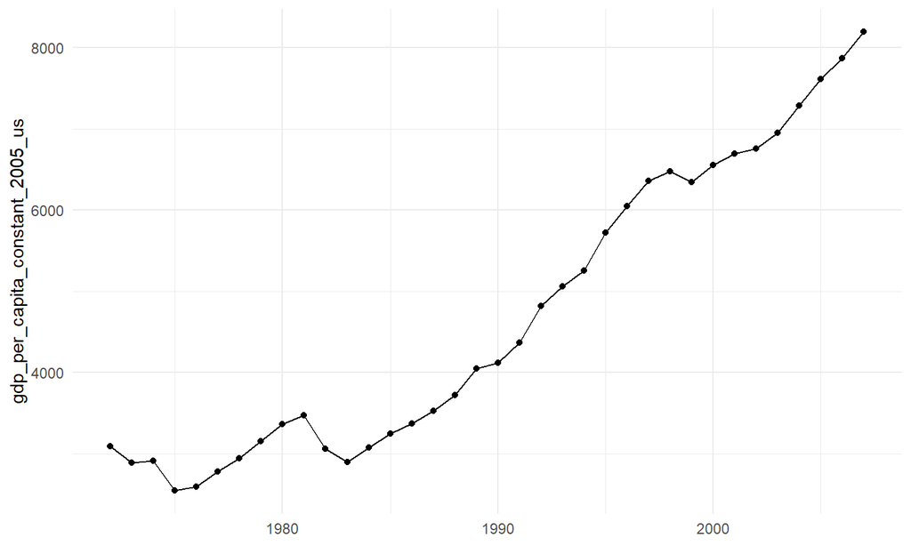

```r
graficos[[1]]
```

```r
graficos[[2]]
```

[output not shown]

## Otra opción

### `map`

```r
library(purrr)
paises <- c("Chile", "Argentina", "United States")
graficos <- map(paises, graf_indicador_pais, gdp_per_capita_constant_2005_us)
```

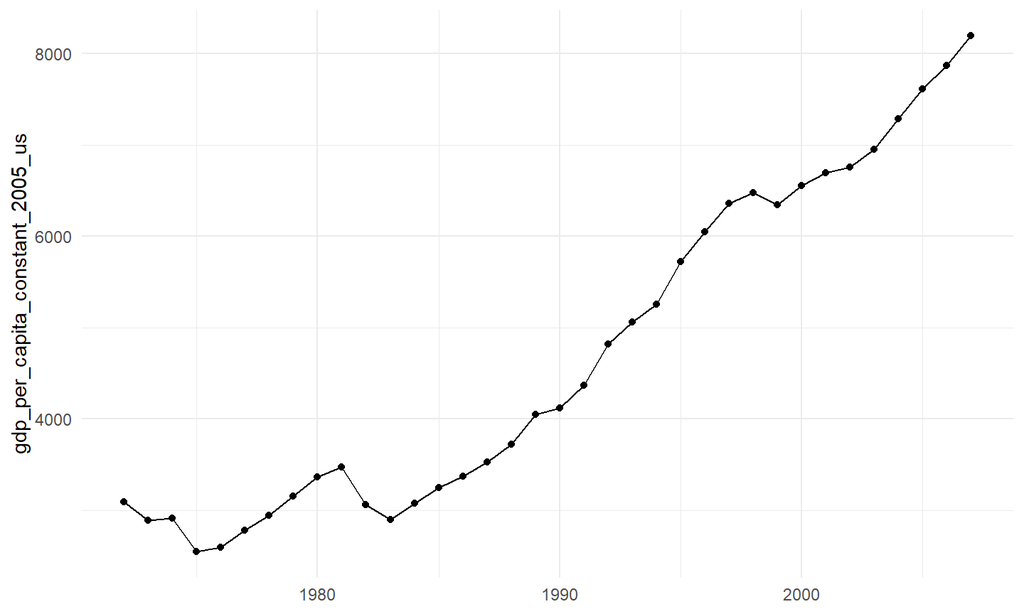

```r
graficos[[1]]
```

```r
graficos[[2]]
```

[output not shown]

## Funciones `map`

- `map()`: resultado es una lista
- `map_lgl()`: resultado es un vector de valores lógicos
- `map_int()`: resultado es un vector de números integrales
- `map_dbl()`: resultado es un vector de números decimales
- `map_chr()`: resultado es un vector de valores tipo texto

## Ejercicio

## Ejercicio

### Script

- `Clase04_EjercicioII.R`

## ¿Qué se viene?

- Próxima clase: regresión vs clasificación
- Tarea 2: sábado 5 de septiembre
- Vayan recopilando sus datos
  - 21 de septiembre: 1ra entrega